# Corces-Buenrostro AML dataset NMF

Health Data Science Unit

Fri Feb 7 13:50:50 2020

# NMF on Gene expression and Chromatin accessibility data

## Gene expression (RNAseq)

### Data loading

Read normalized gene expression matrix…

```r
##----------------------------------------------------------------------------##
##                         Read normalized data                               ##
##----------------------------------------------------------------------------##
# read normalized matrix
rna_norm_mat <- readRDS("data/rnaseq/rnaseq_normalized_counts.RDS")
rna_annotation <- readRDS("data/rnaseq/rnaseq_annotation.RDS")

##----------------------------------------------------------------------------##
##                          Print dataset dimension                           ##
##----------------------------------------------------------------------------##

cat("Dimension of transcriptome dataset (RNAseq):  \n\n  ")
```

Dimension of transcriptome dataset (RNAseq):

```r
kable(data.frame(dim(rna_norm_mat), row.names = c("features", "samples")),
      col.names = "")
```

| features | 21811 |
| --- | --- |
| samples | 45 |

### Applying NMF

Applying Non-Negative Matrix Factorization (NMF) to normalized transcriptome data (RNAseq)

```r
##----------------------------------------------------------------------------##
##                             run NMF                                        ##
##----------------------------------------------------------------------------##
rna_nmf_exp <- runNMFtensor_lite(X                     = rna_norm_mat,
                                 ranks                 = factorization_ranks,
                                 method                = "NMF",
                                 n_initializations     = 5,
                                 iterations            = 10^4,
                                 convergence_threshold = 40,
                                 extract_features = TRUE)
```

```
## [1] "2020-02-07 13:23:26 UTC"
## Factorization rank:  8
## [1] "NMF converged after  230,190,177,180,244 iterations"
## [1] "2020-02-07 13:23:34 UTC"
## Factorization rank:  9
## [1] "NMF converged after  251,165,195,266,252 iterations"
## [1] "2020-02-07 13:23:43 UTC"
## Factorization rank:  10
## [1] "NMF converged after  206,196,191,208,158 iterations"
## No optimal K could be determined from the Optimal K stat
```

```r
rna_nmf_exp
```

```
## class: NMF object lite
## Original matrix dimension:  21811 45
## Factorization performed for ranks:  8 9 10
## Optimal K based on factorization metrics:  Please select manualy
##
## Running parameters:
## method =  NMF
## n_initializations =  5
## iterations =  10000
## stop_threshold =  40
## extract_features =  TRUE
```

```r
## Normalize NMF
rna_norm_nmf_exp <- normalizeW(rna_nmf_exp)
```

### Factorization quality metrics and optimal K

Based on the results of the factorization quality metrics, an optimal number of signatures (k) must be chosen:

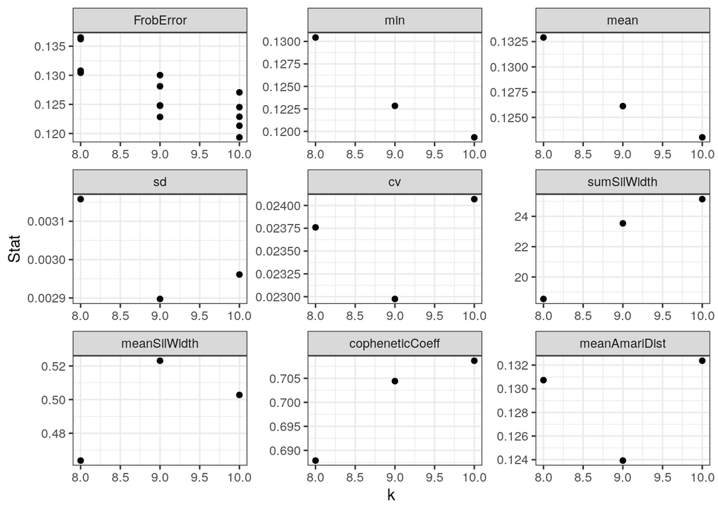

```r
## Plot K stats
gg_plotKStats(rna_norm_nmf_exp)
```

```r
## Generate river plot
#plot(generateRiverplot(rna_norm_nmf_exp), plot_area=1, yscale=0.6, nodewidth=0.5)
```

Minize the Frobenius error, the coefficient of variation and the mean Amari distance, while maximizing the sum and mean silhouette width and the cophenic coefficient.

### H Matrix, W normalized:

```r
##----------------------------------------------------------------------------##
##                        H matrix heatmap annotation                         ##
##----------------------------------------------------------------------------##
#Annotation for H matrix heatmap
# Define color vector
type.colVector <- list(Celltype = setNames(rna_annotation$color[match(levels(rna_annotation$Celltype), rna_annotation$Celltype)],
         levels(rna_annotation$Celltype))
)

# Build Heatmap annotation
heat.anno <- HeatmapAnnotation(df = data.frame(Celltype = rna_annotation$Celltype),
                               col = type.colVector,
                               show_annotation_name = TRUE, na_col = "white")


##----------------------------------------------------------------------------##
##              Generate H matrix heatmap, W normalized                       ##
##----------------------------------------------------------------------------##



for(ki in factorization_ranks) {
  cat("\n")
  cat("  \n#### H matrix for k=",  ki, "  {.tabset}   \n  ")
  #plot H matrix
  tmp.hmatrix <- HMatrix(rna_norm_nmf_exp, k = ki)
  h.heatmap <- Heatmap(tmp.hmatrix,
                       col = viridis(100),
                       name = "Exposure",
                       clustering_distance_columns = 'pearson',
                       show_column_dend = TRUE,
                       heatmap_legend_param =
                         list(color_bar = "continuous", legend_height=unit(2, "cm")),
                       top_annotation = heat.anno,
                       show_column_names = FALSE,
                       show_row_names = FALSE,
                       cluster_rows = FALSE)
  print(h.heatmap)

  cat("  \n Recovery plots for k=",  ki, "  \n  ")

  #recovery_plot(tmp.hmatrix, rna_annotation, "Celltype")

  }
```

#### H matrix for k= 8

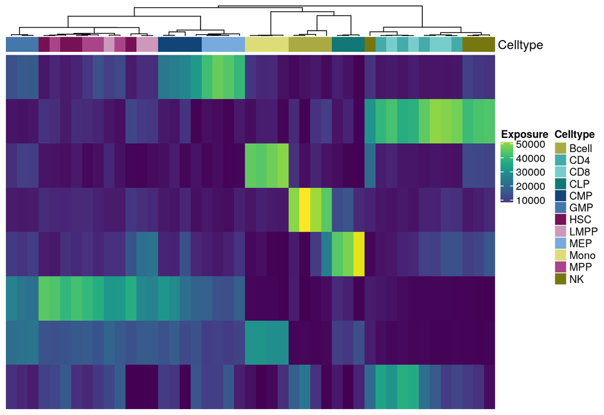

Recovery plots for k= 8

#### H matrix for k= 9

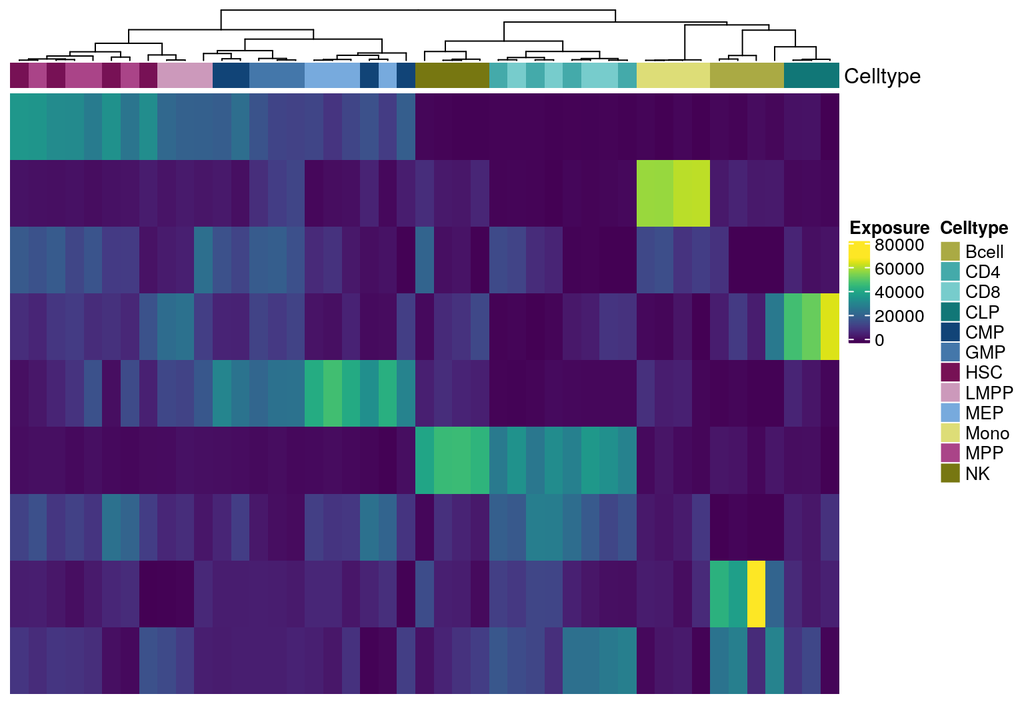

Recovery plots for k= 9

#### H matrix for k= 10

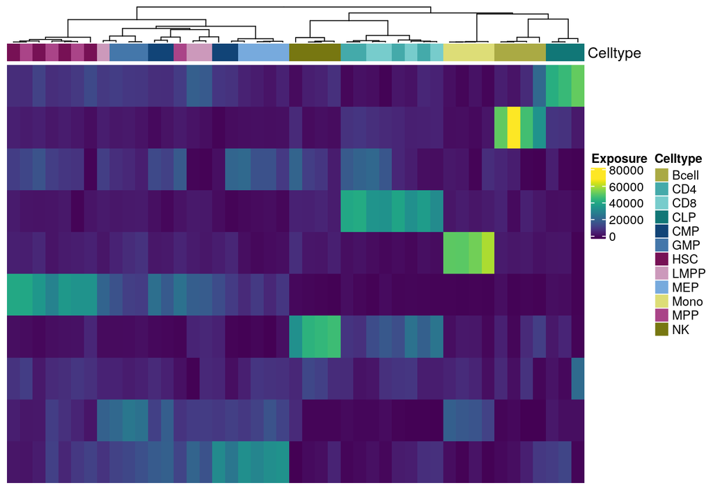

Recovery plots for k= 10

### Gene set enrichment analysis

Using the feature exposure extracted from the W matrix, a gene set enrichment analysis is perform agains all MSigDB terms

The optimal factorization rank selected was: **K = 9**

```r
##----------------------------------------------------------------------------##
##                              W matrix Z scores                             ##
##----------------------------------------------------------------------------##
rna_wmatrix <- WMatrix(rna_norm_nmf_exp, k = 9)

#Zscore for each signature
rna_wmatrix.zscores <- apply(rna_wmatrix, MARGIN=2, function(wmat_score){
  (wmat_score - median(wmat_score)) / mad(wmat_score)
})
colnames(rna_wmatrix.zscores) <- paste0("Signature", 1:9)


##----------------------------------------------------------------------------##
##         GAGE (Generally Applicable Gene-set Enrichment) analysis           ##
##----------------------------------------------------------------------------##
#Infer gene sets tha are significantly pertubed relative to all genes considered
#load precompiled GSEA MSigDB gene sets
gs.msigDB <- readList("db/msigdb.v6.2.symbols.gmt")
# head(gs.msigDB)

#run GAGE analysis
rna_msigDB_enrichment <- gage(rna_wmatrix.zscores, gsets=gs.msigDB, same.dir=TRUE)

#Drop NAs for upregulated
rna_msigDB_enrichment <- as.data.frame(rna_msigDB_enrichment$greater)
rna_msigDB_enrichment <- rna_msigDB_enrichment[!is.na(rna_msigDB_enrichment$p.geomean),]
rna_msigDB_enrichment <- rna_msigDB_enrichment[, paste0("Signature", 1:9)]

# Select only more enriched terms in one signature compared to the others
idx <- apply(rna_msigDB_enrichment, 1, function(term){
  term <- -log10(term)
  # Change 0 to small value to avoid NAs
  term[term == 0] <- 1e-40
  # find if this term is more enriched in one signature compared to others
  is.enrich <- sapply(term, function(x){
    # p-value 5 times greater than at least 5 other signatures
    sum(x/term > 5) > 5
  })
  any(is.enrich)
})

rna_msigDB_enrichment <- rna_msigDB_enrichment[idx,]

# Print table
datatable(rna_msigDB_enrichment, filter="top",
          extensions = 'Buttons',
          options = list(dom = 'Bfrtip',
                         buttons = list(list(extend = 'collection',
                                             buttons = c('excel', 'csv'),
                                             text = 'DOWNLOAD DATA')))) %>%
  formatSignif(columns=colnames(rna_msigDB_enrichment), digits=3)
```

|  | Signature1 | Signature2 | Signature3 | Signature4 | Signature5 | Signature6 | Signature7 | Signature8 | Signature9 |
| --- | --- | --- | --- | --- | --- | --- | --- | --- | --- |
| SHEDDEN_LUNG_CANCER_POOR_SURVIVAL_A6 | 1.33880895864368e-11 | 3.42752047422151e-09 | 3.07751448355083e-11 | 1.79547217407108e-45 | 2.9331266519571e-59 | 4.21398121018593e-06 | 2.23214431046795e-15 | 2.62913434595335e-09 | 7.6576483063867e-07 |
| RUTELLA_RESPONSE_TO_CSF2RB_AND_IL4_DN | 2.39036788921565e-11 | 1.10772494748684e-66 | 1.34221076444548e-10 | 1.48068891625092e-10 | 2.31319973292708e-09 | 3.13335654033556e-09 | 1.13270287797393e-08 | 1.24773947220784e-09 | 0.00028688057191938 |
| GSE29618_BCELL_VS_MONOCYTE_DN | 8.19315726626318e-11 | 3.04724403079628e-74 | 8.48360341879392e-13 | 1.04423268283477e-07 | 3.68040013448884e-12 | 4.5725681765115e-08 | 1.41698842688102e-11 | 0.0012055311220149 | 0.0250476592838698 |
| GSE29618_BCELL_VS_MONOCYTE_DAY7_FLU_VACCINE_UP | 1.28813118673563e-09 | 0.00216563804233125 | 0.0655961666334976 | 6.99605564240043e-21 | 4.94633910154056e-07 | 3.38764981015964e-11 | 4.24446163682349e-05 | 3.70886057649616e-58 | 7.45941765881061e-22 |
| GSE29618_BCELL_VS_PDC_DAY7_FLU_VACCINE_UP | 2.54875170463395e-07 | 1.36372883487958e-11 | 0.107105615879947 | 6.6606229133841e-15 | 0.000105300682694436 | 1.3721970386303e-11 | 3.56825440191878e-06 | 1.83369500869695e-56 | 3.66008914400847e-19 |
| GSE22886_NAIVE_BCELL_VS_MONOCYTE_DN | 4.33431340438186e-06 | 2.50629551382325e-63 | 2.82118529184301e-19 | 7.06439593885099e-06 | 2.73177439607537e-11 | 1.71210866840654e-10 | 8.93016138167948e-10 | 5.65315424022317e-07 | 0.0366943748311996 |
| RUTELLA_RESPONSE_TO_HGF_VS_CSF2RB_AND_IL4_UP | 8.00500855043153e-13 | 2.01114979917208e-55 | 1.15715658219659e-07 | 9.32720106410117e-11 | 2.38064831943838e-12 | 1.49125111497805e-08 | 8.19281119657768e-06 | 3.57666754199736e-08 | 0.000766290395700323 |
| GSE29618_BCELL_VS_MDC_UP | 4.15021608567414e-07 | 4.30233381983374e-07 | 0.34291681480226 | 5.41065783943941e-18 | 6.21982997414642e-05 | 1.9997283475275e-11 | 1.3619407074314e-05 | 2.61741137149774e-60 | 4.43475803105255e-21 |
| GSE29618_BCELL_VS_MDC_DAY7_FLU_VACCINE_UP | 2.0643261916444e-08 | 6.51976668610881e-05 | 0.227404763797564 | 8.53208409077019e-19 | 2.48158888107471e-05 | 8.939787370468e-10 | 0.000123558281197166 | 4.16215073845226e-58 | 5.15093956993691e-22 |
| GSE29618_BCELL_VS_MONOCYTE_UP | 1.71771439207474e-07 | 0.0137643275638004 | 0.057376867095837 | 2.64899842304724e-20 | 2.17893590225171e-07 | 3.16389731009122e-09 | 2.59454983010821e-05 | 2.10460459833417e-59 | 6.36687528675557e-19 |

[output cut: 1723 more lines]

## Chromatin accessibility (ATACseq)

### Data loading

Read normalized chromatin accessibility matrix…

```r
##----------------------------------------------------------------------------##
##                         Read normalized data                               ##
##----------------------------------------------------------------------------##
# read normalized matrix
atac_norm_mat <- readRDS("data/atacseq/atacseq_normalized_counts.RDS")
atac_annotation <- readRDS("data/atacseq/atacseq_annotation.RDS")

##----------------------------------------------------------------------------##
##                          Print dataset dimension                           ##
##----------------------------------------------------------------------------##

cat("Dimension of Chromatin accessibility dataset (ATACseq):  \n\n  ")
```

Dimension of Chromatin accessibility dataset (ATACseq):

```r
kable(data.frame(dim(atac_norm_mat), row.names = c("features", "samples")),
      col.names = "")
```

| features | 123102 |
| --- | --- |
| samples | 68 |

### Applying NMF

Applying Non-Negative Matrix Factorization (NMF) to normalized Chromatin accessibility data (ATACseq)

```r
##----------------------------------------------------------------------------##
##                             run NMF                                        ##
##----------------------------------------------------------------------------##
atac_nmf_exp <- runNMFtensor_lite(X                     = atac_norm_mat,
                                  ranks                 = factorization_ranks,
                                  method                = "NMF",
                                  n_initializations     = 5,
                                  iterations            = 10^4,
                                  convergence_threshold = 40,
                                  extract_features = FALSE)
```

```
## [1] "2020-02-07 13:25:13 UTC"
## Factorization rank:  8
## [1] "NMF converged after  268,174,231,305,234 iterations"
## [1] "2020-02-07 13:25:50 UTC"
## Factorization rank:  9
## [1] "NMF converged after  214,251,335,285,207 iterations"
## [1] "2020-02-07 13:26:32 UTC"
## Factorization rank:  10
## [1] "NMF converged after  185,200,221,239,259 iterations"
```

```r
atac_nmf_exp
```

```
## class: NMF object lite
## Original matrix dimension:  123102 68
## Factorization performed for ranks:  8 9 10
## Optimal K based on factorization metrics:  9
## Running parameters:
## method =  NMF
## n_initializations =  5
## iterations =  10000
## stop_threshold =  40
## extract_features =  FALSE
```

```r
## Normalize NMF
atac_norm_nmf_exp <- normalizeW(atac_nmf_exp)
```

### Factorization quality metrics and optimal K

Based on the results of the factorization quality metrics, an optimal number of signatures (k) must be chosen:

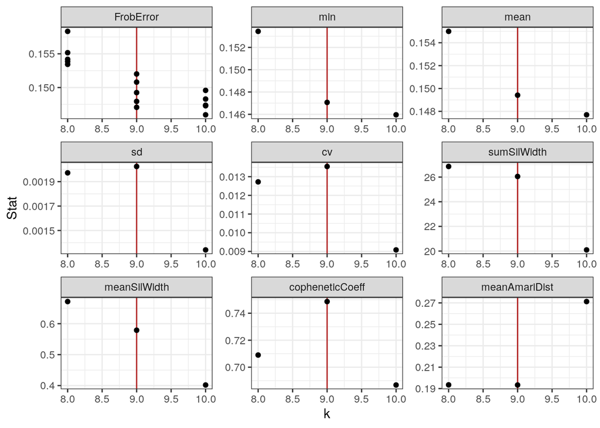

```r
## Plot K stats
gg_plotKStats(atac_norm_nmf_exp)
```

```r
## Generate river plot
#plot(generateRiverplot(atac_norm_nmf_exp), plot_area=1, yscale=0.6, nodewidth=0.5)
```

Minize the Frobenius error, the coefficient of variation and the mean Amari distance, while maximizing the sum and mean silhouette width and the cophenic coefficient.

### H Matrix, W normalized:

```r
##----------------------------------------------------------------------------##
##                        H matrix heatmap annotation                         ##
##----------------------------------------------------------------------------##
#Annotation for H matrix heatmap
# Define color vector
type.colVector <- list(Celltype = setNames(atac_annotation$color[match(levels(atac_annotation$Celltype), atac_annotation$Celltype)],
         levels(atac_annotation$Celltype))
)

# Build Heatmap annotation
heat.anno <- HeatmapAnnotation(df = data.frame(Celltype = atac_annotation$Celltype),
                               col = type.colVector,
                               show_annotation_name = TRUE, na_col = "white")


##----------------------------------------------------------------------------##
##              Generate H matrix heatmap, W normalized                       ##
##----------------------------------------------------------------------------##
for(ki in factorization_ranks) {
  cat("\n")
  cat("  \n#### H matrix for k=",  ki, "  {.tabset}   \n  ")
  #plot H matrix
  tmp.hmatrix <- HMatrix(atac_norm_nmf_exp, k = ki)
  h.heatmap <- Heatmap(tmp.hmatrix,
                       col = viridis(100),
                       name = "Exposure",
                       clustering_distance_columns = 'pearson',
                       show_column_dend = TRUE,
                       heatmap_legend_param =
                         list(color_bar = "continuous", legend_height=unit(2, "cm")),
                       top_annotation = heat.anno,
                       show_column_names = FALSE,
                       show_row_names = FALSE,
                       cluster_rows = FALSE)
  print(h.heatmap)

  cat("  \n Recovery plots for k=",  ki, "  \n  ")

  #recovery_plot(tmp.hmatrix, atac_annotation, "Celltype")

  }
```

#### H matrix for k= 8

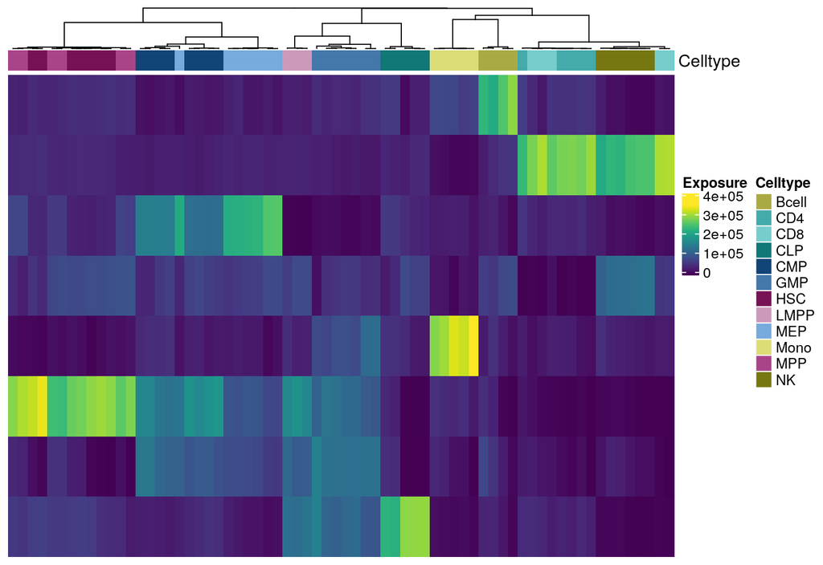

Recovery plots for k= 8

#### H matrix for k= 9

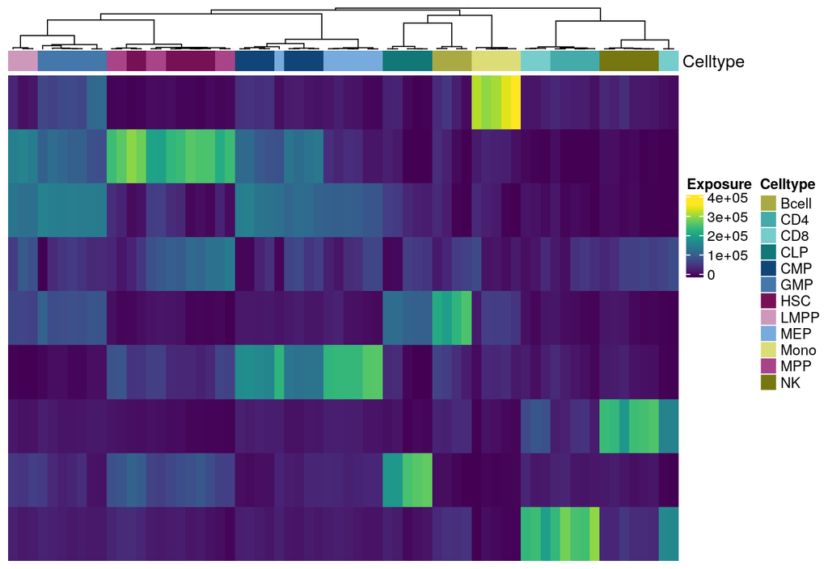

Recovery plots for k= 9

#### H matrix for k= 10

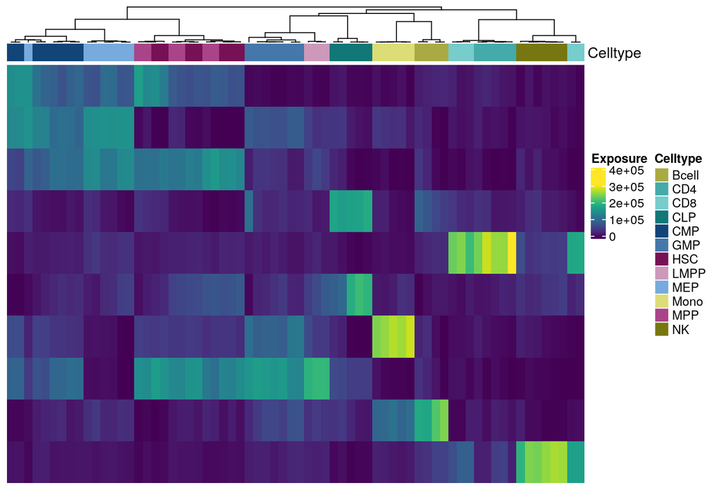

Recovery plots for k= 10

```r
gc()
```

```
    used  (Mb) gc trigger  (Mb) max used  (Mb)
```

Ncells 10577076 564.9 15261564 815.1 15261564 815.1 Vcells 35021022 267.2 58064634 443.0 47607859 363.3

## Integrative RNAseq & ATACseq

**Gene expression (RNAseq) & Chromatin accessibility (ATACseq)**

Only the those samples with RNAseq and ATACseq data were used in the integrative analysis.

### Data loading

Read normalized gene expression matrix and chromatin accessibility matrix…

```r
##----------------------------------------------------------------------------##
##                         Read normalized data                               ##
##----------------------------------------------------------------------------##
# read normalized matrix
int_norm_mat <- readRDS("data/multiview/multiview_norm_mat_list.RDS")
int_annotation <- readRDS("data/multiview/multiview_annotation.RDS")

##----------------------------------------------------------------------------##
##                          Print dataset dimension                           ##
##----------------------------------------------------------------------------##
cat("Dimension of transcriptome dataset (RNAseq):  \n\n  ")
```

Dimension of transcriptome dataset (RNAseq):

```r
kable(data.frame(dim(int_norm_mat$rna), row.names = c("features", "samples")),
      col.names = "")
```

| features | 21811 |
| --- | --- |
| samples | 24 |

```r
cat("Dimension of Chromatin accessibility dataset (ATACseq):  \n\n  ")
```

Dimension of Chromatin accessibility dataset (ATACseq):

```r
kable(data.frame(dim(int_norm_mat$atac), row.names = c("features", "samples")),
      col.names = "")
```

| features | 123102 |
| --- | --- |
| samples | 24 |

### integrative NMF Lambda tuning

In iNMF the lambda parameter controls if the factorization should shift towards extracting more homogeneous effect or heterogeneous effect.

Based on Yang and Michailidis, 2016, to tune the value of the parameter lambda for the integrative NMF (iNMF), the objectives values of join NMF (jNMF) are compared to single view NMFs (sNMF), the principle is that join NMF represents complete homogeneity and single view NMF represents complete heterogeneity.

To avoid overfitting the best lambda can be selected by plotting the difference of the unsquared residual quantities of jNMF and iNMF (Ri - Rj) over multiple values of lambda, and compare it to the difference of the unsquared residual quantities of sNMF and jNMF c*(Rj - Rs). The optimal lambda usually is the first lambda in which (Ri - Rj) < c*(Rj - Rs). Where c is a constant >= 2.

For more Help please run *?iNMF_lambda_tuning.*

The following function helps to select the optimal lamba for a fixed factorization rank (K = 9).

```r
##----------------------------------------------------------------------------##
##                             Run integrative NMF                            ##
##----------------------------------------------------------------------------##
iNMF_lambda_tuning(matrix_list           = int_norm_mat,
                   lambdas               = seq(0, 1, 0.1),
                   thr_cons              = 4,
                   Output_type           = "residuals",
                   rank                  = 9,
                   n_initializations     = 1,
                   iterations            = 10^4,
                   convergence_threshold = 40)
```

```
## Running join NMF for views:  rna,atac
## [1] "2020-02-07 13:27:20 UTC"
## Factorization rank:  9
## [1] "join NMF converged after  85 iterations"
## No optimal K could be determined from the Optimal K stat
## Running single view NMF for :  rna
## [1] "2020-02-07 13:27:22 UTC"
## Factorization rank:  9
## [1] "NMF converged after  118 iterations"
## No optimal K could be determined from the Optimal K stat
## Running single view NMF for :  atac
## [1] "2020-02-07 13:27:23 UTC"
## Factorization rank:  9
## [1] "NMF converged after  253 iterations"
## No optimal K could be determined from the Optimal K stat
## Testing lamda :  0
## Running integrative NMF for views:  rna,atac
## [1] "2020-02-07 13:27:27 UTC"
## Factorization rank:  9
## [1] "integrative NMF converged after  172 iterations"
## No optimal K could be determined from the Optimal K stat
## Testing lamda :  0.1
## Running integrative NMF for views:  rna,atac
## [1] "2020-02-07 13:27:32 UTC"
## Factorization rank:  9
## [1] "integrative NMF converged after  196 iterations"
## No optimal K could be determined from the Optimal K stat
## Testing lamda :  0.2
## Running integrative NMF for views:  rna,atac
## [1] "2020-02-07 13:27:38 UTC"
## Factorization rank:  9
## [1] "integrative NMF converged after  133 iterations"
## No optimal K could be determined from the Optimal K stat
## Testing lamda :  0.3
## Running integrative NMF for views:  rna,atac
## [1] "2020-02-07 13:27:42 UTC"
## Factorization rank:  9
## [1] "integrative NMF converged after  190 iterations"
## No optimal K could be determined from the Optimal K stat
## Testing lamda :  0.4
```

[output cut: 26 more lines]

```
## Factorization rank:  9
## [1] "integrative NMF converged after  113 iterations"
## No optimal K could be determined from the Optimal K stat
## Testing lamda :  0.9
## Running integrative NMF for views:  rna,atac
## [1] "2020-02-07 13:28:14 UTC"
## Factorization rank:  9
## [1] "integrative NMF converged after  218 iterations"
## No optimal K could be determined from the Optimal K stat
## Testing lamda :  1
## Running integrative NMF for views:  rna,atac
## [1] "2020-02-07 13:28:21 UTC"
## Factorization rank:  9
## [1] "integrative NMF converged after  136 iterations"
## No optimal K could be determined from the Optimal K stat
```

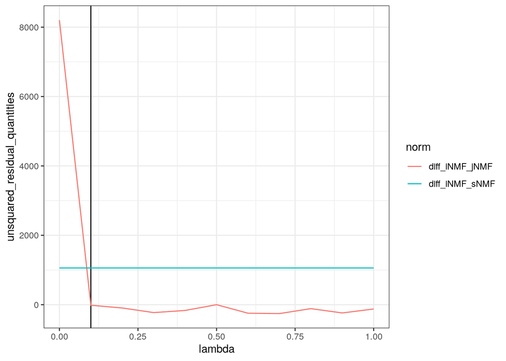

```
##    norm_jnmf norm_snmf norm_inmf lambda diff_iNMF_jNMF diff_iNMF_sNMF
## 1   1781.002  1516.435  1656.976    1.0  -124.02570683       1058.266
## 2   1781.002  1516.435  1542.933    0.9  -238.06889820       1058.266
## 3   1781.002  1516.435  1667.507    0.8  -113.49522701       1058.266
## 4   1781.002  1516.435  1524.531    0.7  -256.47090121       1058.266
## 5   1781.002  1516.435  1535.436    0.6  -245.56565880       1058.266
## 6   1781.002  1516.435  1781.028    0.5     0.02592826       1058.266
## 7   1781.002  1516.435  1614.982    0.4  -166.01940249       1058.266
## 8   1781.002  1516.435  1553.245    0.3  -227.75718007       1058.266
## 9   1781.002  1516.435  1685.656    0.2   -95.34540374       1058.266
## 10  1781.002  1516.435  1765.031    0.1   -15.97080702       1058.266
## 11  1781.002  1516.435  9982.487    0.0  8201.48567908       1058.266
##    best_lambda
## 1        FALSE
## 2        FALSE
## 3        FALSE
## 4        FALSE
## 5        FALSE
## 6        FALSE
## 7        FALSE
## 8        FALSE
## 9        FALSE
## 10        TRUE
## 11       FALSE
```

According to the figure, the optimal lamba should be between 0.1 and 0.3

### Applying integrative NMF

Applying Integrative Non-Negative Matrix Factorization (NMF) to normalized Gene expression (RNAseq) and Chromatin accessibility data (ATACseq)

```r
##----------------------------------------------------------------------------##
##                             Run integrative NMF                            ##
##----------------------------------------------------------------------------##
inmf_exp <- run_iNMF_tensor(matrix_list           = int_norm_mat,
                            ranks                 = factorization_ranks,
                            n_initializations     = 5,
                            iterations            = 10^4,
                            convergence_threshold = 40,
                            Sp                    = 0,
                            lamb                  = 0.1,
                            extract_features      = FALSE)
```

```
## Running integrative NMF for views:  rna,atac
## [1] "2020-02-07 13:28:26 UTC"
## Factorization rank:  8
## [1] "integrative NMF converged after  228,185,226,207,223 iterations"
## [1] "2020-02-07 13:28:59 UTC"
## Factorization rank:  9
## [1] "integrative NMF converged after  159,167,171,165,178 iterations"
## [1] "2020-02-07 13:29:24 UTC"
## Factorization rank:  10
## [1] "integrative NMF converged after  159,135,235,144,142 iterations"
## No optimal K could be determined from the Optimal K stat
```

```r
inmf_exp
```

```
## class: integrative NMF object
## Original matrices dimensions:  rna,21811,24 atac,123102,24
## Factorization performed for ranks:  8 9 10
## Optimal K based on factorization metrics:  Please select manualy
##
## Running parameters:
## method = integrative NMF
## lamb =  0.1
## n_initializations =  5
## iterations =  10000
## stop_threshold =  40
## extract_features =  FALSE
```

### Factorization quality metrics and optimal K

Based on the results of the factorization quality metrics, an optimal number of signatures (k) must be chosen:

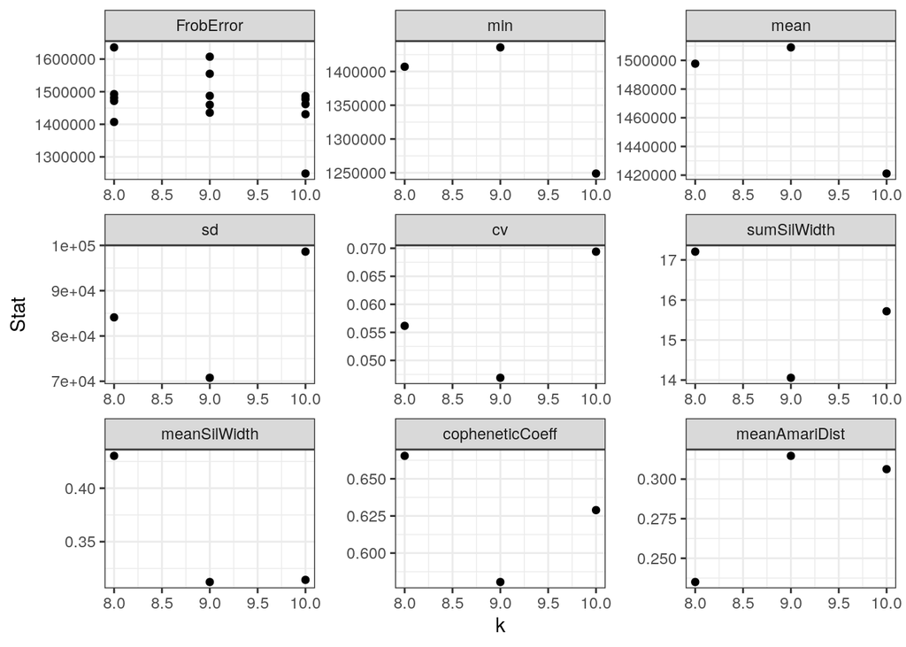

```r
## Plot K stats
gg_plotKStats(inmf_exp)
```

Minize the Frobenius error, the coefficient of variation and the mean Amari distance, while maximizing the sum and mean silhouette width and the cophenic coefficient.

### H Matrices:

```r
##----------------------------------------------------------------------------##
##                    Plot H matrix heatmap integrative NMF                   ##
##----------------------------------------------------------------------------##


plotH_oneView <- function(int_nmf, viewID, k, heat.anno, main_hist, col=viridis(100),
                          scale_color=TRUE, displayID = viewID){

  sharedH <- HMatrix(int_nmf, k = k, type = "shared")
  Hview   <- HMatrix(int_nmf, k = k, type = "viewspec", view_id = viewID)


  # hs   <- HMatrix(inmf_exp, k = ki, type = "shared")
  # hv_r <- HMatrix(inmf_exp, k = ki, type = "viewspec", view_id = "rna")
  # hv_a <- HMatrix(inmf_exp, k = ki, type = "viewspec", view_id = "atac")

  # Define total H matrix
  totalH <- sharedH + Hview
  # Color Function
  if (scale_color) {
    colf <- circlize::colorRamp2(seq(0, max(totalH), length.out = 100), col)
  } else {
    colf <- col
  }

  #main_hist <- hclust(as.dist(1 - cor(totalH, method = "pearson")))

  tH.heatmap <- Heatmap(totalH,
                        col = colf,
                        name = "Total Exposure",
                        column_title = "Total H matrix",
                        cluster_columns = main_hist,
                        show_column_dend = TRUE,
                        top_annotation = heat.anno,
                        show_column_names = FALSE,
                        show_row_names = FALSE,
                        cluster_rows = FALSE)

  sH.heatmap <- Heatmap(sharedH,
                        col = colf,
                        name = "Shared Exposure",
                        column_title = "Shared H matrix",
                        cluster_columns = main_hist,
                        show_column_dend = TRUE,
                        top_annotation = heat.anno,
                        show_column_names = FALSE,
                        show_row_names = FALSE,
                        cluster_rows = FALSE)

  vH.heatmap <- Heatmap(Hview,
                        col = colf,
                        name = "View Specific Exposure",
                        column_title = "View specific H matrix",
                        cluster_columns = main_hist,
                        show_column_dend = TRUE,
                        top_annotation = heat.anno,
                        show_column_names = FALSE,
                        show_row_names = FALSE,
                        cluster_rows = FALSE)
  #print(tH.heatmap + sH.heatmap + vH.heatmap)
  # stiff_cor_heat <- as_ggplot(grid.grabExpr(draw(stiff_cor_heat)))
  # stiff_cor_heat

  #ht_global_opt(heatmap_legend_grid_height = unit(.25, "cm"))
  ht_list <- tH.heatmap + sH.heatmap + vH.heatmap
  draw(ht_list, row_title = displayID)
  ht_global_opt(RESET = TRUE)
}


##----------------------------------------------------------------------------##
##                        H matrix heatmap annotation                         ##
##----------------------------------------------------------------------------##
#Annotation for H matrix heatmap
# Define color vector
type.colVector <- list(Celltype = setNames(int_annotation$color[match(levels(int_annotation$Celltype), int_annotation$Celltype)],
         levels(int_annotation$Celltype))
)

# Build Heatmap annotation
heat.anno <- HeatmapAnnotation(df = data.frame(Celltype = int_annotation$Celltype),
                               col = type.colVector,
                               show_annotation_name = FALSE, na_col = "white")


my_Heatmap <- function(my_h, heat.anno, matrix_id){
  hm <- Heatmap(my_h,
                col = viridis(100),
                name = matrix_id,
                column_title = matrix_id,
                cluster_columns = main_hist,
                        show_column_dend = TRUE,
                        top_annotation = heat.anno,
                        show_column_names = FALSE,
                        show_row_names = FALSE,
                        cluster_rows = FALSE)

}


##----------------------------------------------------------------------------##
##              Generate H matrix heatmap, W normalized                       ##
##----------------------------------------------------------------------------##
for(ki in factorization_ranks) {
  cat("\n")
  #cat("  \n#### H matrix for k=",  ki, "  {.tabset}   \n  ")
  cat("  \n#### H matrix for k=",  ki, "  {.tabset}    \n  ")
  #plot H matrix
  cat("\n")
  cat("  \n##### not scaled  \n  ")


  sharedH <- HMatrix(inmf_exp, k = ki, type = "shared")
  main_hist <- hclust(as.dist(1 - cor(sharedH, method = "pearson")))




  plotH_oneView(inmf_exp, k = ki, heat.anno = heat.anno, main_hist = main_hist,
                scale_color = FALSE, viewID = "rna", displayID = "RNAseq")
  plotH_oneView(inmf_exp, k = ki, heat.anno = heat.anno, main_hist = main_hist,
                scale_color = FALSE, viewID = "atac", displayID = "ATACseq")

  cat("\n")
  cat("  \n##### scaled  \n  ")
  plotH_oneView(inmf_exp, k = ki, heat.anno = heat.anno, main_hist = main_hist,
                scale_color = TRUE, viewID = "rna", displayID = "RNAseq")
  plotH_oneView(inmf_exp, k = ki, heat.anno = heat.anno, main_hist = main_hist,
                scale_color = TRUE, viewID = "atac", displayID = "ATACseq")


  }
```

#### H matrix for k= 8

##### not scaled

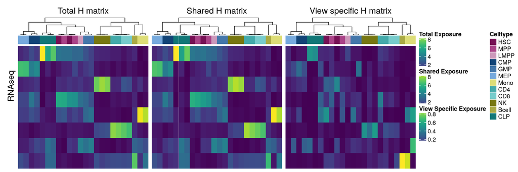

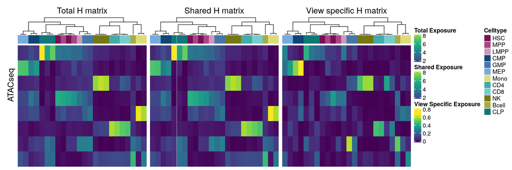

##### scaled

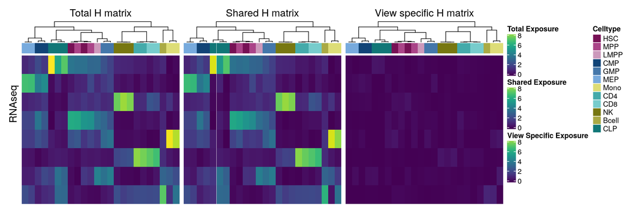

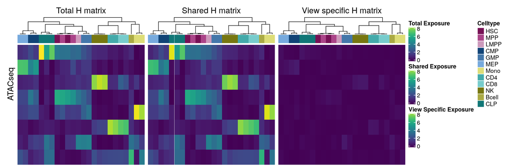

#### H matrix for k= 9

##### not scaled

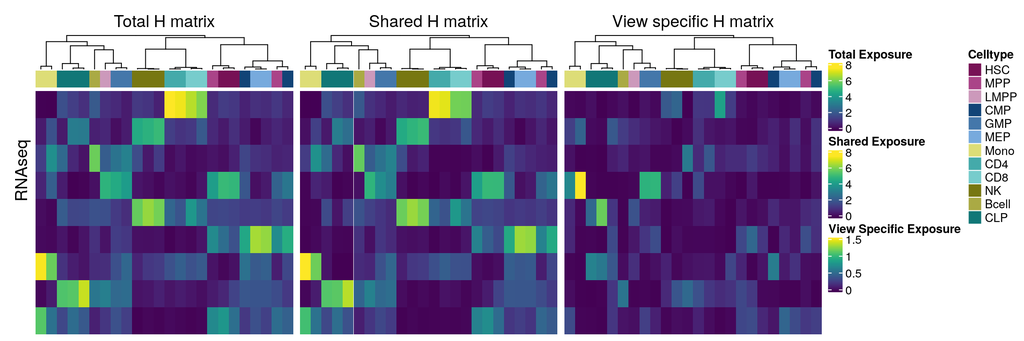

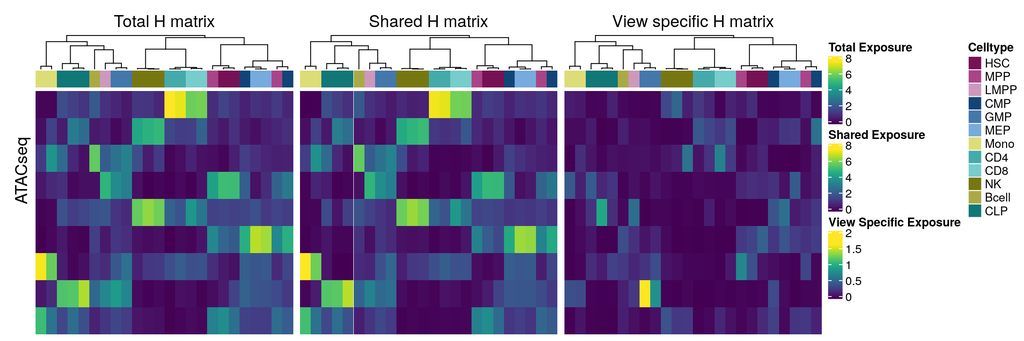

##### scaled

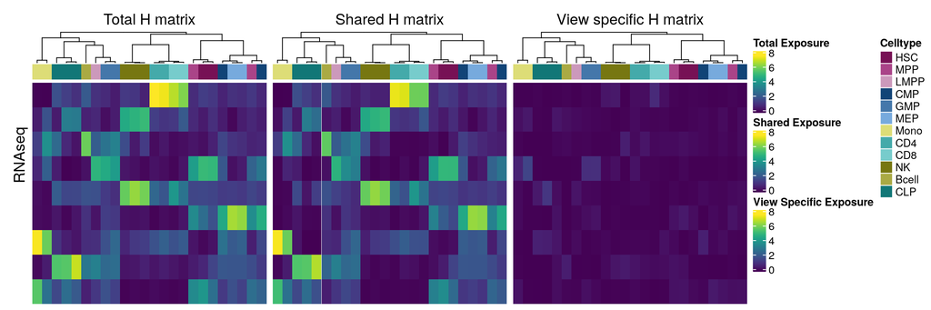

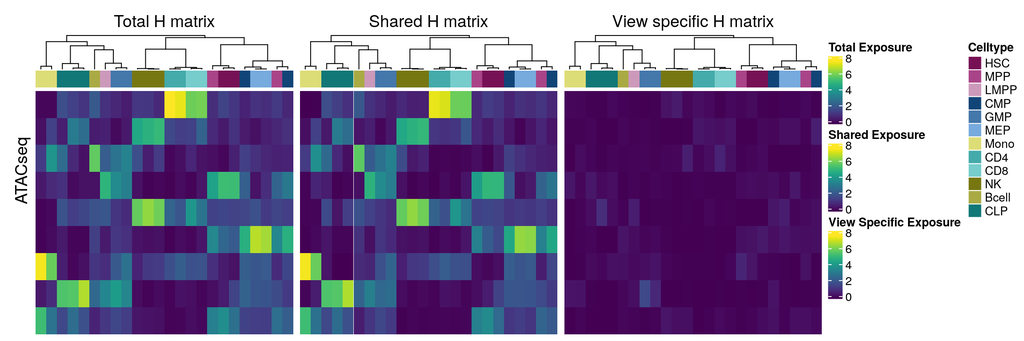

#### H matrix for k= 10

##### not scaled

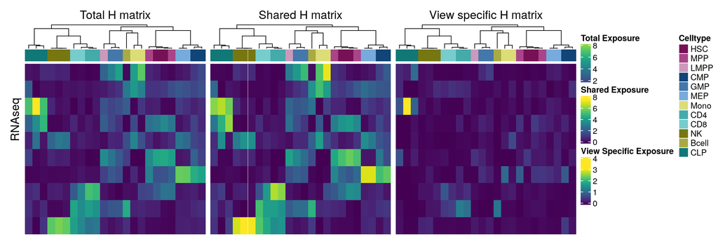

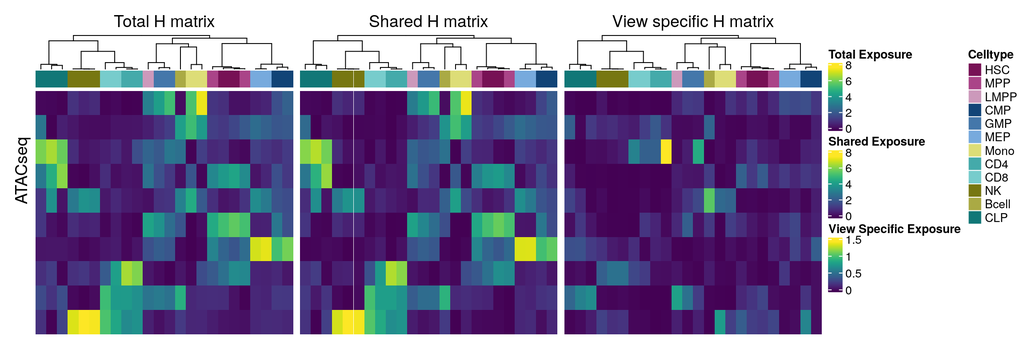

##### scaled

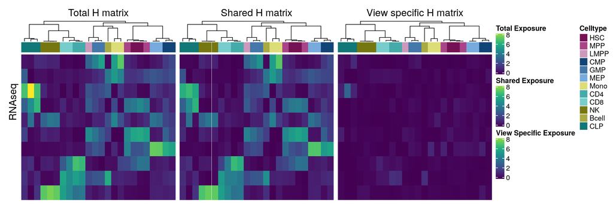

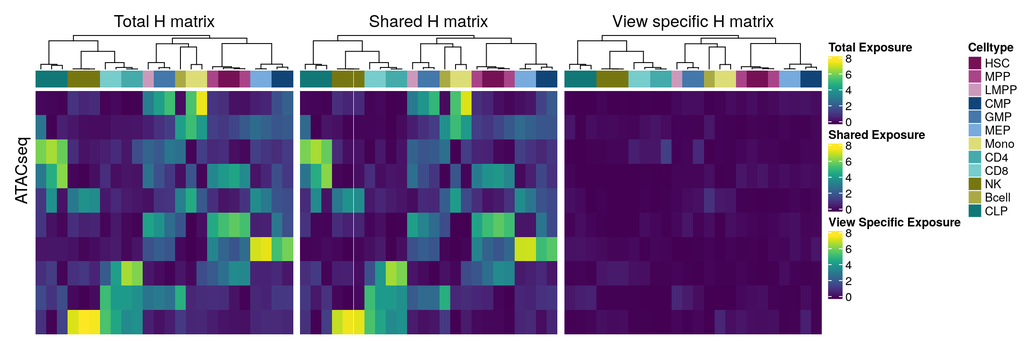

### Gene set enrichment analysis

Using the feature exposure extracted from the W matrix, a gene set enrichment analysis is perform agains all MSigDB terms

The optimal factorization rank selected was: **K = 9**

```r
##----------------------------------------------------------------------------##
##                              W matrix Z scores                             ##
##----------------------------------------------------------------------------##
int_rna_wmatrix <- WMatrix(inmf_exp, k = 9, view_id = "rna",)

#Zscore for each signature
int_rna_wmatrix.zscores <- apply(int_rna_wmatrix, MARGIN=2, function(wmat_score){
  (wmat_score - median(wmat_score)) / mad(wmat_score)
})
colnames(int_rna_wmatrix.zscores) <- paste0("Signature", 1:9)


##----------------------------------------------------------------------------##
##         GAGE (Generally Applicable Gene-set Enrichment) analysis           ##
##----------------------------------------------------------------------------##
#Infer gene sets tha are significantly pertubed relative to all genes considered
#load precompiled GSEA MSigDB gene sets
gs.msigDB <- readList("db/msigdb.v6.2.symbols.gmt")
# head(gs.msigDB)

#run GAGE analysis
int_rna_msigDB_enrichment <- gage(int_rna_wmatrix.zscores, gsets=gs.msigDB, same.dir=TRUE)

#Drop NAs for upregulated
int_rna_msigDB_enrichment <- as.data.frame(int_rna_msigDB_enrichment$greater)
int_rna_msigDB_enrichment <- int_rna_msigDB_enrichment[!is.na(int_rna_msigDB_enrichment$p.geomean),]
int_rna_msigDB_enrichment <- int_rna_msigDB_enrichment[, paste0("Signature", 1:9)]

# Select only more enriched terms in one signature compared to the others
idx <- apply(int_rna_msigDB_enrichment, 1, function(term){
  term[term == 0] <- 1e-40
  term <- -log10(term)
  # Change 0 to small value to avoid NAs
  # find if this term is more enriched in one signature compared to others
  is.enrich <- sapply(term, function(x){
    # p-value 5 times greater than at least 5 other signatures
    sum(x/term > 5) > 5
  })
  any(is.enrich)
})

# table(idx)
# head(idx)
# head(int_rna_msigDB_enrichment)
int_rna_msigDB_enrichmentf <- int_rna_msigDB_enrichment[idx,]

# Print table
datatable(int_rna_msigDB_enrichmentf, filter="top",
          extensions = 'Buttons',
          options = list(dom = 'Bfrtip',
                         buttons = list(list(extend = 'collection',
                                             buttons = c('excel', 'csv'),
                                             text = 'DOWNLOAD DATA')))) %>%
  formatSignif(columns=colnames(int_rna_msigDB_enrichment), digits=3)
```

|  | Signature1 | Signature2 | Signature3 | Signature4 | Signature5 | Signature6 | Signature7 | Signature8 | Signature9 |
| --- | --- | --- | --- | --- | --- | --- | --- | --- | --- |
| GSE29618_BCELL_VS_MONOCYTE_DN | 0.00417688127157073 | 2.70841664277701e-12 | 2.49195167028047e-09 | 1.19647998513685e-13 | 0.00214754112166278 | 0.00298627081935707 | 5.04469661691174e-61 | 0.00235009003880002 | 1.0667032357959e-18 |
| GSE22886_NAIVE_BCELL_VS_MONOCYTE_DN | 0.0137242380576055 | 1.33435428869594e-12 | 9.4253079868955e-10 | 2.19140950804328e-08 | 0.000250743283977377 | 0.00743207346679866 | 1.48101064912624e-55 | 0.0102275650792871 | 6.19329056861245e-16 |
| GSE45739_UNSTIM_VS_ACD3_ACD28_STIM_NRAS_KO_CD4_TCELL_UP | 5.38780134404141e-37 | 8.36794247747301e-08 | 7.09958764677149e-05 | 8.80947970434319e-08 | 1.57857308652931e-05 | 3.84667915395436e-06 | 4.12873828152338e-11 | 1.60108880849129e-07 | 1.20688467587698e-06 |
| HADDAD_B_LYMPHOCYTE_PROGENITOR | 9.74943067827336e-11 | 1.14978960412745e-09 | 5.46937984234609e-07 | 0.245424098880312 | 2.01518713090726e-07 | 0.00759463690918426 | 0.0005803367914937 | 2.77240258496377e-57 | 1.0980891108162e-09 |
| GSE29618_PDC_VS_MDC_DN | 0.00915391025416632 | 6.5541770069787e-08 | 3.77991094120857e-15 | 1.0846150114747e-08 | 0.000284741840130174 | 0.01936078263139 | 4.41464821497903e-46 | 0.0170213506234439 | 2.46653945001562e-14 |
| GSE22886_NAIVE_TCELL_VS_NKCELL_UP | 1.66106772361432e-34 | 4.77566075513145e-06 | 6.42283345692069e-07 | 7.68865373110438e-07 | 3.58695929681484e-05 | 2.3825515106903e-08 | 6.91644940773203e-06 | 1.55281315127667e-06 | 8.35777623031942e-08 |
| GSE10325_LUPUS_CD4_TCELL_VS_LUPUS_MYELOID_UP | 6.00387394145139e-49 | 6.69106973506451e-12 | 0.0032497692519112 | 2.07671257311657e-05 | 1.91504896096142e-18 | 4.95516593390557e-05 | 0.136258309350175 | 5.98850925978925e-06 | 0.0223828320014509 |
| SOTIRIOU_BREAST_CANCER_GRADE_1_VS_3_UP | 0.119427565860227 | 1.48408083362703e-11 | 0.000989021071702557 | 2.31951084558821e-08 | 0.94122102813031 | 3.75550622137953e-26 | 8.20207993975348e-05 | 2.51831260310451e-42 | 1.83401655724425e-08 |
| GSE29618_PDC_VS_MDC_DAY7_FLU_VACCINE_DN | 0.0377339739436498 | 1.51115657712443e-09 | 2.26386154039875e-13 | 1.56004765090822e-08 | 0.00205488387399258 | 0.0068214213810747 | 4.043023437377e-45 | 0.0526994231458729 | 1.96072391885874e-11 |
| GSE10325_CD4_TCELL_VS_MYELOID_UP | 3.86988249940742e-50 | 3.97767483354879e-18 | 0.154949823727466 | 1.36251894279987e-07 | 9.02344207283372e-14 | 6.13705939592067e-05 | 0.00405522617265107 | 0.000583017163912908 | 0.370651673422147 |

[output cut: 1255 more lines]